# Homework 6

## Transforming predictors before smoothing

If a variable is very (say) right-skewed and we don’t have all that many measurements of it, we’ll have lots of closely-spaced observations at small values, and a few widely-spaced observations at large values. Trying to find **one** smoothing bandwidth which works well for both parts of the data would be hard. In principle, with enough observations this doesn’t matter, and splines are somewhat more robust to this effect than are kernels, but it can still be a difficulty. Transforming the predictor before smoothing can help reveal structure which would otherwise be smothered.

## Using the built-in cross-validation in `gam()`

Alternatively, we could use the `cv.gam` function from the earlier lecture. There will be some differences, since what `gam` computes is really the “generalized” cross-validation score, a fast approximation to leave-one-out CV that avoids having to refit the model $n$ times (see Section 3.4.3 of the notes). The circulated code, on the other hand, is for $k$-fold CV, defaulting to $k=5$.

## Bootstrapping the smooths

Really, we shouldn’t trust the confidence bands that `gam` plots for us. So we could bootstrap those as well. This is a little bit painful however, so you aren’t expected to do it. I’ve done it below though. This is the main reason that I kept around the entire fitted model for each bootstrap replication: I can re-use the fits here and just calculate summaries rather than repeating the entire exercise.

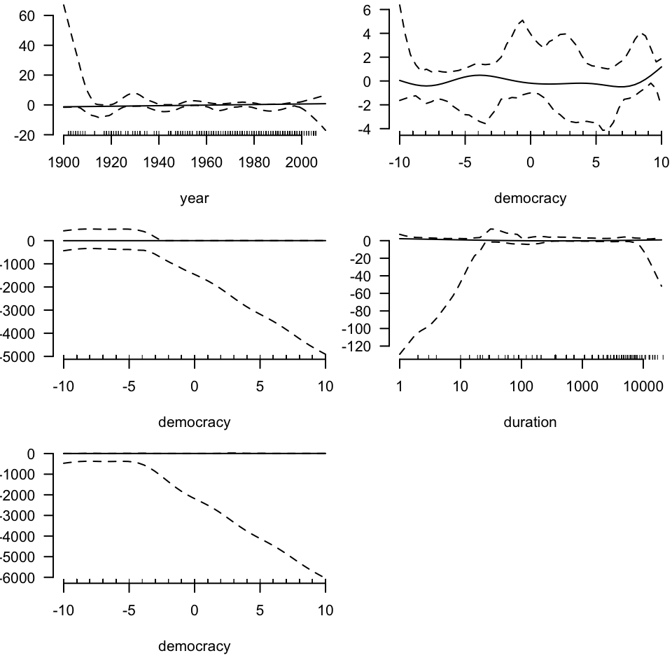

Figure A1: Bootstrap confidence bands. The bottom figure is for the sum of democracy terms.

## Choice of bootstrap

|  | lo | est | hi |
| --- | --- | --- | --- |
| (Intercept) | -3.844 | -0.362 | 2.384 |
| nonviol | -609.234 | 3.123 | 206.186 |
| viol.repress | -2.782 | -0.650 | 1.175 |
| sanctions | -1.785 | -0.045 | 2.010 |
| aid | -1.302 | 0.098 | 1.781 |
| support | -0.846 | 0.716 | 2.059 |
| defect | -0.220 | 0.913 | 2.509 |
| nonviol:viol.repress | -3.425 | -0.574 | 387.514 |

## Details of bootstrapping

While the resampling scheme is the same for both the parametric and non-parametric parts of the model, and we want confidence intervals for both, we need slightly different pieces of code for the coefficients on indicators and for the partial response functions. When dealing with the coefficients, we treat them like any other set of parameters, e.g., the coefficients in a linear regression. We can extract them from a fitted model with `summary()$p.coef`, or by taking the appropriately-named entries in the vector returned by `coefficients`. On the other hand, the partial response functions are **functions**, curves, and we need to get confidence bands for them the way we got confidence bands for spline and kernel regressions, using `predict`.

Because fitting a GAM is comparatively slow, it would be better not to have to do a completely separate set of resamplings and re-estimations for every term in the model. The code thus modifies the example code from the notes and homework solutions to let different terms in the model share the same set of bootstrap samples. This is, of course, beyond what you were expected to do.

## Model checking: Classification and calibration

The techniques, and the solution code, are lifted from chapter 11 and 12 lectures.

It would have been ever better to check calibration in a cross-validatory way, but that would go beyond what was required here.

## Model checking: Comparing to another model

The assignment called for using a GAM. In the notes and homework, we looked at using a GAM to test whether a GLM is well-specified; we can’t really turn that around. Even if we had fit a GLM here, and then rejected it, that would just have said “the GAM isn’t as bad as the GLM”, not “the GAM is a good model”. We could try embedding the GAM in a more general model, such as a kernel regression, or conditional kernel density estimate, or even just a GAM with a lot more interactions, and tested it along similar lines, however.

## Model checking: What to do with a bad model?

If any of the checks had detected severe problems with the model, the ideal course would have been to look into **why** the model was bad, and come up with a new one which fixed those problems. The **report** could have been written around the fixed-up model, with at most a brief mention of discarded predecessors. If we couldn’t find a tolerable model, then we’d have to say why even our best model wasn’t acceptable; some of the ways we’d tried and failed to fix it; and how the model’s problems might impair our ability to use its estimates to answer the analytical questions.

## Variable selection

The assignment did **not** call for variable selection or an extensive search over models. It was nonetheless legitimate to do such a search, provided one did so intelligently. Deleting variables from a model because their coefficients or partial response functions are insignificant is **not** a reliable method (as you learned in 431). With the model fit here, even though it has substantial predictive ability, **not one single term** is significant at the 5% level. Cross-validation would work much better.

It should hardly need repeating that “this variable’s coefficient or response function was not statistically significant” does **not** mean the same thing as “this variable does not matter for predicting the response”. A very wide confidence interval which overlaps with 0 means we **don’t know** whether or how much the variable matters. It is only when the confidence interval contains zero **and** is very small that we can be pretty sure the variable is unimportant. (For that matter, a tiny confidence interval which does not include zero, but is centered around a minute value, is also good reason to think that a variable doesn’t matter very much.)

[^1]: See, for example, George Orwell’s 1949 essay “Reflections on Gandhi”.
[^2]: People who were in a hospital a year ago are more likely to be dead now than those who weren’t, but not, for the most part, because their doctors killed them.
[^3]: Which could also be a selection effect: why waste it on a movement bound to fail?
[^4]: Perhaps the reverse of the selection-effect story for aid to the government?
[^5]: But perhaps another selection effect: deserting an already-losing side.
[^6]: Cf. Fred Halliday, *Revolution and World Politics: The Rise and Fall of the Sixth Great Power* (Durham, North Carolina: Duke University Press, 1999).
[^7]: Note that *really* we should bootstrap the bands around the smooths as well. I did this in the appendix, because it’s a bit painful. But do have a look.